# Data Visualisation

Ben Whalley

September 2026

# Inspiration

In the session we watched Hans Rosling’s “200 countries and 200 years in 4 minutes”, which we (hopefully) agreed is something to aspire to. Combined with his enthusiastic presentation, the visualisations in this clip support a clear narrative and help us understand a complex dataset.

[video not shown]

The plot he builds is interesting because it uses many different visual attributes (aesthetics) to express features in the data, including:

- X and Y axes
- Colour
- Size of the points
- Time (in the animation)

These features are carefully selected to highlight important features of the data and support the narrative he provides. Although we need to have integrity in our plotting (we discuss bad examples in the session), this narrative aspect of a plot is important: we always need to consider our audience.

# Before you start

Use the ‘files pane’ in RStudio to make a new folder on the RStudio server to save your work. Call this `datafluency202_x_`.

Inside this new folder, make a new RMarkdown file (use the ‘file’ menu and choose ‘new’). When you save the file make sure it has the extension `.rmd`, so call it `datavis.rmd` for example.

Use this new `.rmd` file to save your work during this session.

[video not shown]

# Recreate the Rosling plot

*“Multi-dimensional plotting”* sounds fancy, but it just means linking different visual features of a plot to multiple columns in a dataset.

In the example, Rosling’s plot is appealing and informative because it adds multiple dimensions, and uses a special [logarithmic scale](https://blog.datawrapper.de/weeklychart-logscale/) for the x-axis.

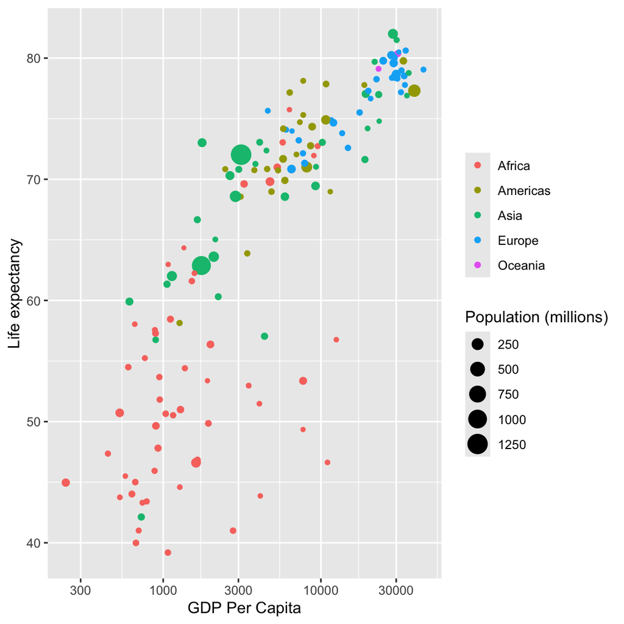

- The Rosling plot shown above has dimensions
- The additional dimension in the plot shown in the BBC video is:
- x axis (GDP)
- y axis (life exp.)
- color (continent)
- size (population)

*Time* is the extra dimension, because it shows these other values changing across years.

## Defining dimensions/aesthetics

As a reminder: `ggplot` uses the term **aesthetics** to refer to different dimensions of a plot.

‘*Aesthetics*’ refers to ‘what things look like’, and the `aes()` command in `ggplot` maps variables (columns in the dataset) to visual features of the plot.

There are 4 visual features (aesthetics) of plots we will use in this session:

- the `x` axis
- the `y` axis
- `colour`
- `size` (of points)

We could also use:

- the `fill` colour of shaded areas
- `shape` (of points)
- `linewidth` (the thickness of lines)
- `linetype` (of added lines, i.e. dotted/patterned or solid)
- transparency (called `alpha`) of the features of a plot

(If interested, ask ChatGPT how to add these aesthetics to your plots).

Additionally, we will control the scale of the axes in the plot to improve the presentation of the data.

Rosling’s plot looked something like this:

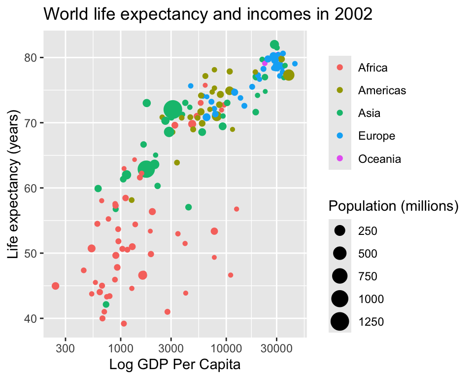

To create a (slightly simplified) version of the plot above, the code would look something like this:

```r
development %>%
  filter(BLANK==BLANK)  %>%
  ggplot(aes(x=BLANK,
             y=BLANK,
             size=BLANK,
             color=BLANK)) +
  geom_point() +
  scale_x_log10() +
  labs(x=BLANK, y=BLANK, color=BLANK, size=BLANK)
```

I have removed some parts of the code. Your job is to edit the parts which say `<BLANK>` and replace them with the names of variables from the `development` dataset (available in the `psydata` package).

Some hints:

- All the `BLANK`s represent variable names in the dataset. You can see a list of the column names available by typing `glimpse(development)`
- If you are confused by the `filter(BLANK==BLANK)` check the *title* of the plot above. Remember that `filter` [selects particular rows from the data](https://plymouthpsychology.github.io/cheatR/lifesavr_cheatsheet.html#filtering-datasets), so we can use it to restrict what is shown in the plot. What data do we need to select for *this* plot?
- The part which reads `scale_log_10()` is explained in more detail below
- The part which reads `labs(...)` sets the axis labels (ask ChatGPT about it)

Video hints:

[video not shown]

# Using multiple layers

When visualizing data, there’s always more than one way to do things. As well as plotting different dimensions, different *types* of plot can highlight different features of the data. In ggplot, different types of plots are called **geometries**. Multiple layers can be combined in the same plot by adding together commands which have the prefix “`geom_`”.

As we have already seen, `geom_point()` is used to create a scatter plot:

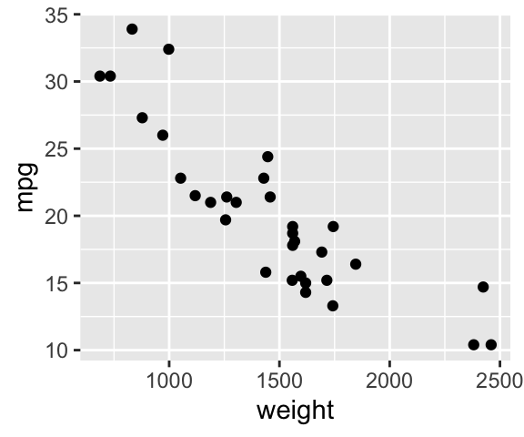

To add additional layers to this plot, we can add extra `geom_<NAME>` functions. For example, `geom_smooth` is used to overlay a smooth line to any x/y plot:

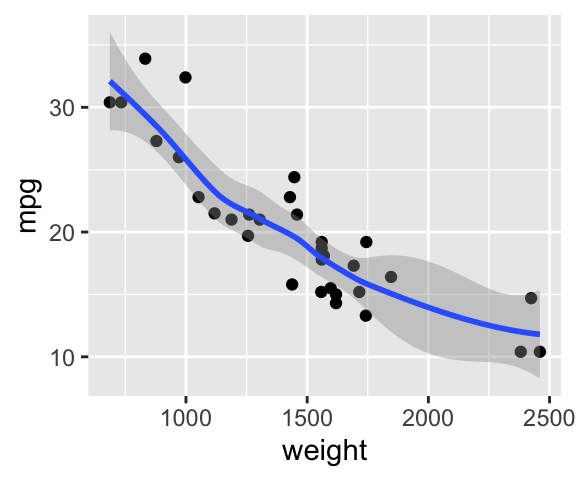

```r
fuel %>%
  ggplot(aes(weight, mpg)) +
  geom_point() +
  geom_smooth()
```

**Explanation of the command**: We added `+ geom_smooth()` to our previous plot. This means we now have two geometries added to the same plot: `geom_point` and `geom_smooth`.

**Explanation of the output**: The plot shown is the same as the previous scatterplot, but now has a smooth blue line overlaid. This represents the local-average of `mpg`, for each level of `weight`. There is also a grey-shaded area, which represents the standard error of the local average (again there will be more on this later in the course).

We could add other layers to the plot with other `geom_` functions.

For example, we could calculate the median `mpg` of all cars in the dataset and overlay that as a horizontal line:

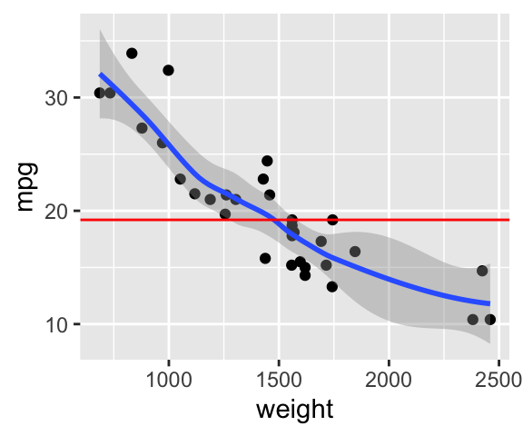

```r
med_mpg <- fuel %>% summarise(median(mpg)) %>% pull(1)

fuel %>%
  ggplot(aes(weight, mpg)) +
  geom_point() +
  geom_smooth() +
  geom_hline(yintercept = med_mpg, color="red")
```

*Explanation of the code* First we calculate the median of `mpg` using summarise. Then we use the `pull(1)` command for the first time. This selects the first column of data (containing our median) and returns only that. That is, it returns only a number, or a list of numbers, rather than the whole dataframe. Then we added the `geom_hline` function to our existing plot. We set the `yintercept` option to the stored `med_mpg` value, and this defines the height of the line. We added `color="red"` to make the added line distinctive.

*Explanation of the output* The plot is the same as before, but now has a red line marked at the median of the `mpg` column. The red line is on top of the other plot elements because we added this line at the end of our plotting code.

*Make your own layered plot*

1. Use the `mentalh` data-set from `psydata`. Create a scatter plot of screen time and anxiety scores, adapting the code above.
2. Add a smoothed line to the plot using `geom_smooth()`
3. Colour the plot, using the `education` variable.
4. Add a horizontal line to the plot, with the `yintercept` set to the median anxiety score.

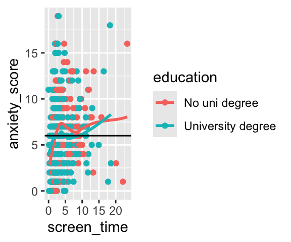

```r
med_anx <- mentalh %>% summarise(median(anxiety_score)) %>% pull(1)

mentalh %>%
  ggplot(aes(screen_time, anxiety_score, color=education)) +
  geom_point() +
  geom_smooth(se=F) +
  geom_hline(yintercept = med_anx)
```

# Scales

## Incomes are “not normal”

If we re-plot the development data using the default settings in ggplot you might notice that the result looks quite different to the one shown in the video or the exercise above.

In particular, the *placement* of the points looks quite different:

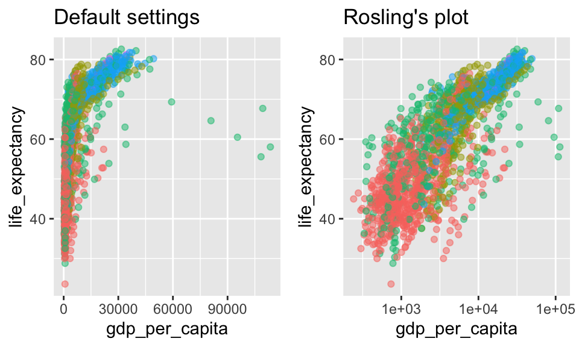

Specifically, we can see that in the left hand panel the points are mostly compressed to the left hand of the frame. In contrast, in the original plot, the points are fairly evenly spread across the x-axis.

These plots are showing the same data. The only difference is that *the original plot uses a **log scale***.

We can recognise the log scale by looking at the markings on the x axis:

- In the left hand panel the markings go up by 30,000 each time.
- In the original plot, each marker represents a value *10 times larger* than the previous. So, 1000, 10,000 and 100,000 (the values shown are in [scientific notation](https://www.calculatorsoup.com/calculators/math/scientific-notation-converter.php), so `1e+03` means 1000).

## Skewed distributions

Another way to see why this helps is to plot the distribution of incomes:

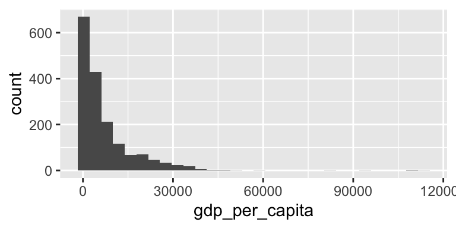

```r
development %>%
  ggplot(aes(gdp_per_capita)) +
  geom_histogram()
```

*Explanation of the code* We used the `geom_histogram` function to make histogram of the GDP per capita variable.

*Explanation of the output* The histogram shows that most GDP values are below $20,000, but a small number are much, much larger (i.e. > $100,000). This is quite typical of incomes data.

We can then add `scale_x_log10()` to the same plot:

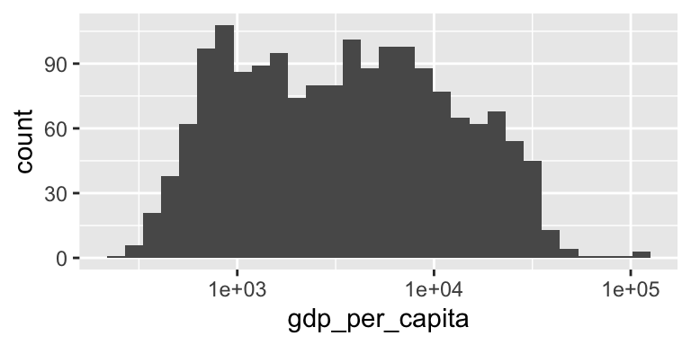

```r
development %>%
  ggplot(aes(gdp_per_capita)) +
  geom_histogram() +
  scale_x_log10()
```

*Explanation of the code* We make another, histogram this time adding `scale_x_log10()`.

*Explanation of the output* The plot changes, and the distribution is less skewed. We can see that the scale markers are again in scientific notation, and the gaps between points of the scale are not equal: each point on the scale is 10 times larger than the previous one (1000, 10,000, 100,000), stretching out the values across the x axis and reducing the skew.

## Reaction times

In the example above we saw that incomes were not normally distributed and benefited from a log scale. Another common example of ‘non-normal’ data are those from reaction time studies.

For example:

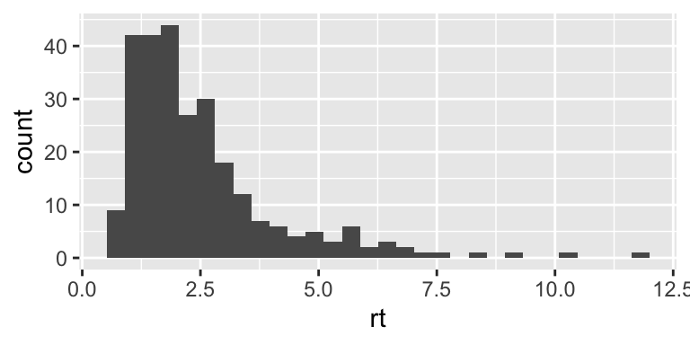

```r
rtdata <- read_csv('https://raw.githubusercontent.com/lindeloev/shiny-rt/master/mrt_data.csv')

rtdata %>%
  ggplot(aes(rt)) +
  geom_histogram()
```

*Explanation of the code* The line with `read_csv` takes a web address (URL) and reads a ‘comma separated values’ data file from it. The next part makes a histogram using the reaction time (RT) data it contains. In case it is truncated in the output above, the full url is: [`https://raw.githubusercontent.com/lindeloev/shiny-rt/master/mrt_data.csv`](https://raw.githubusercontent.com/lindeloev/shiny-rt/master/mrt_data.csv)

*Explanation of the output* The RT data are strongly skewed. Consequently the median, 2.01, is lower than the mean value, 2.51.

1. Copy and paste the line of code which reads the CSV data and run it.
2. Recreate the histogram above (use `geom_histogram`) or a density plot (use `geom_density`)
3. Add the correct scale function to recreate this plot:

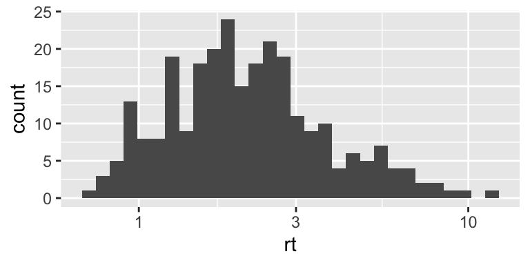

```r
rtdata <- read_csv('https://raw.githubusercontent.com/lindeloev/shiny-rt/master/mrt_data.csv')

rtdata %>%
  ggplot(aes(rt)) +
  geom_histogram() +
  scale_x_log10()
```

Or

```r
rtdata <- read_csv('https://raw.githubusercontent.com/lindeloev/shiny-rt/master/mrt_data.csv')

rtdata %>%
  ggplot(aes(rt)) +
  geom_density() +
  scale_x_log10()
```

# Animation!

*This is an entirely optional exercise. It is not required for the course assessment and is included only because students asked how to make animations similar to the one shown in the Rosling video. Skip to the next section if you are short on time.*

The `gganimate` package allows us to create animations using ggplot. The package has good documentation here: https://gganimate.com.

As an example we can load the package:

```r
library(gganimate)
```

`gganimate` is already installed on the school’s RStudio server. If you are using R on your own computer and see the error `there is no package called 'gganimate'`, install it (and `gifski`, which it uses to make the animated GIF) by running this once in the **Console**:

```r
install.packages(c("gganimate", "gifski"))
```

And then adapt our previous ggplot by adding `transition_time(year)`. This adds `year` as a time-based dimension, animating the plot.

We need to save the resulting plot in a variable, and then send that to the `animate` function. Here we use a variable called `progress_plot`.

```r
progress_plot <- development %>%
  ggplot(aes(gdp_per_capita, life_expectancy, color=continent)) +
  geom_point() +
  scale_x_log10() +
  transition_time(year)
```

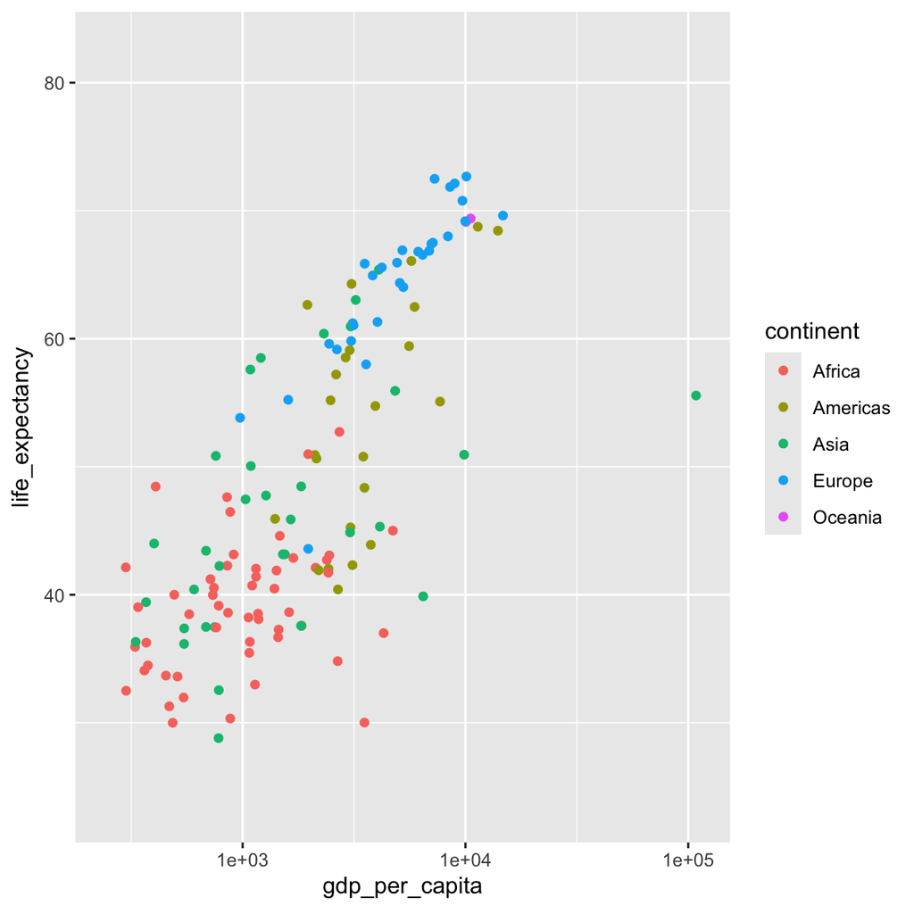

```r
animate(progress_plot,   nframes = 50)
```

Try to animate the following plot using data from all the years in the `development` dataset. To do this, amend the code below, referring to the example above:

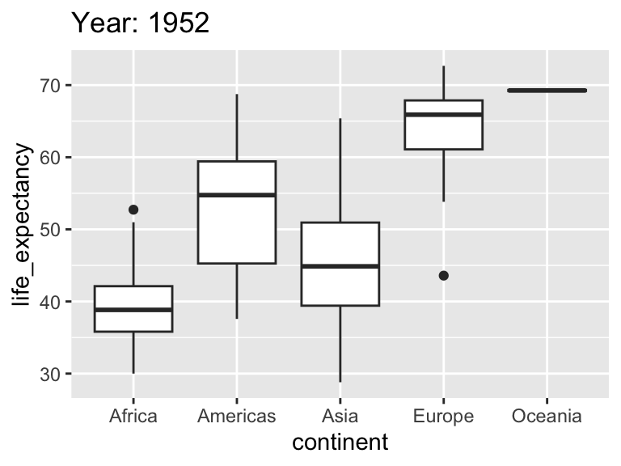

```r
development %>%
  filter(year == 1952) %>%
  ggplot(aes(continent, life_expectancy)) +
  geom_boxplot() +
  labs(title="Year: 1952")
```

You need to:

- Remove the filter
- Use the `transition_time()` function

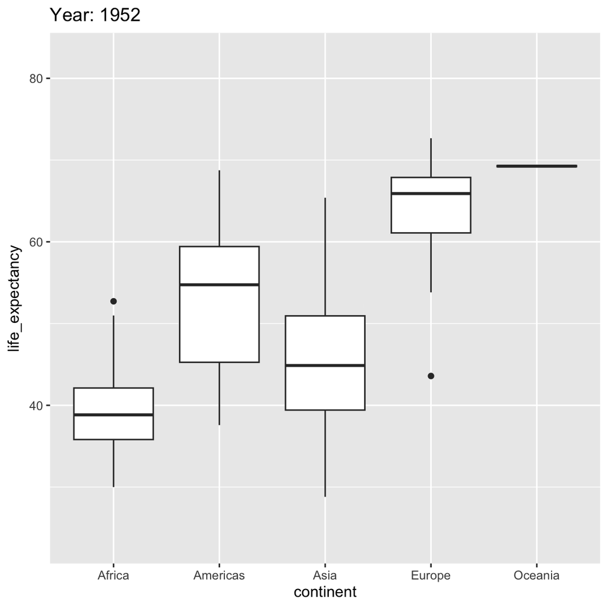

```r
library(tidyverse)
library(psydata)
library(gganimate)

p <- development %>%
  ggplot(aes(continent, life_expectancy)) +
  geom_boxplot() +
  labs(title = "Year: {frame_time}") +
  transition_time(year)

p %>% animate()
```

The text `{frame_time}` inside the title is replaced by the year currently shown in each frame of the animation.

# Graphics are for answering questions

*Note: you do not need to have completed the extension exercise using animation to engage with this activity.*

In this section you don’t need to make any plots yourself: The task is to consider a range of different ways of plotting similar data and to think about which plots are best suited to a range of different tasks.

Consider the following plots:

- An animated boxplot
- Standard boxplot
- Line graph
- Ribbon plot

#### Animated boxplot

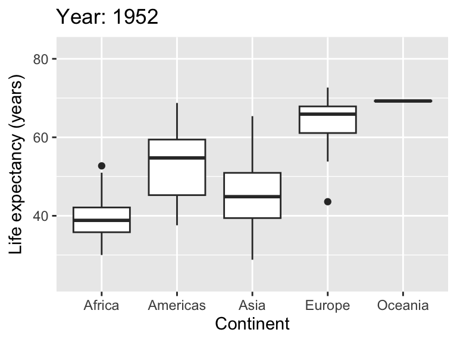

#### Boxplot

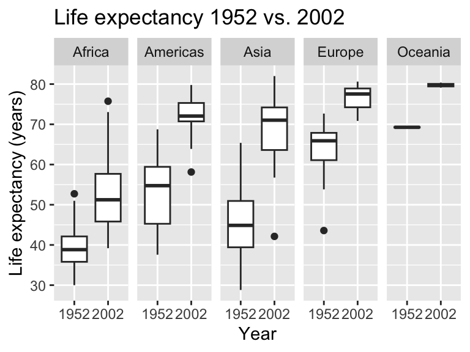

#### Line graph

This plot shows the median life expectancy in 1952 and 2002.

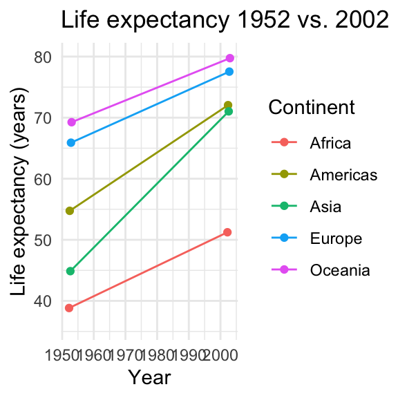

#### Ribbon plot

This plot shows the median (line) and IQR (shaded area) in all available years:

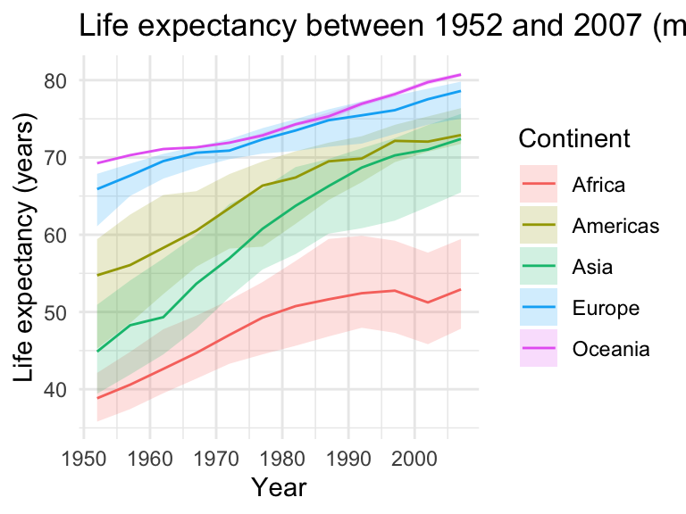

1. Make a table of the strengths and weaknesses of each plot, like so:

| Plot | Strengths | Weaknesses |
| --- | --- | --- |
| Animated boxplot | … | … |
| Boxplot | … | … |
| Line graph | … | … |
| … | … | … |

(on paper/in your notes is fine)

2. Think of some *questions* that can be answered from these data? For example:
- *Which continent changed most between 1952 and 2002?*
- *Which continent has the most variability in life expectancy?*

Your questions might consider factors such as change, rates of change, comparisons between high/low performing countries, heterogeneity/homogeneity among countries, and so on. Make a list of at least 5 or 6 questions which someone might want to know the answer to.

3. Which plots are most effective in answering each of your questions? Can you identify trade-offs between different plot types?
4. Imagine you were a journalist writing a story with the title *“Asia sees fastest rise in life expectancy since WW2”*. Why might you prefer the line graph over the boxplot? What are the pros and cons of the line plot compared with the ribbon plot?

# Facets

As we add layers or visual aesthetics (e.g. colours, shapes, lines) our plots become more complex. We may run into trade-offs between information density and clarity.

To give one example, this plot shows life expectancies for each country in the development data, plotted by year:

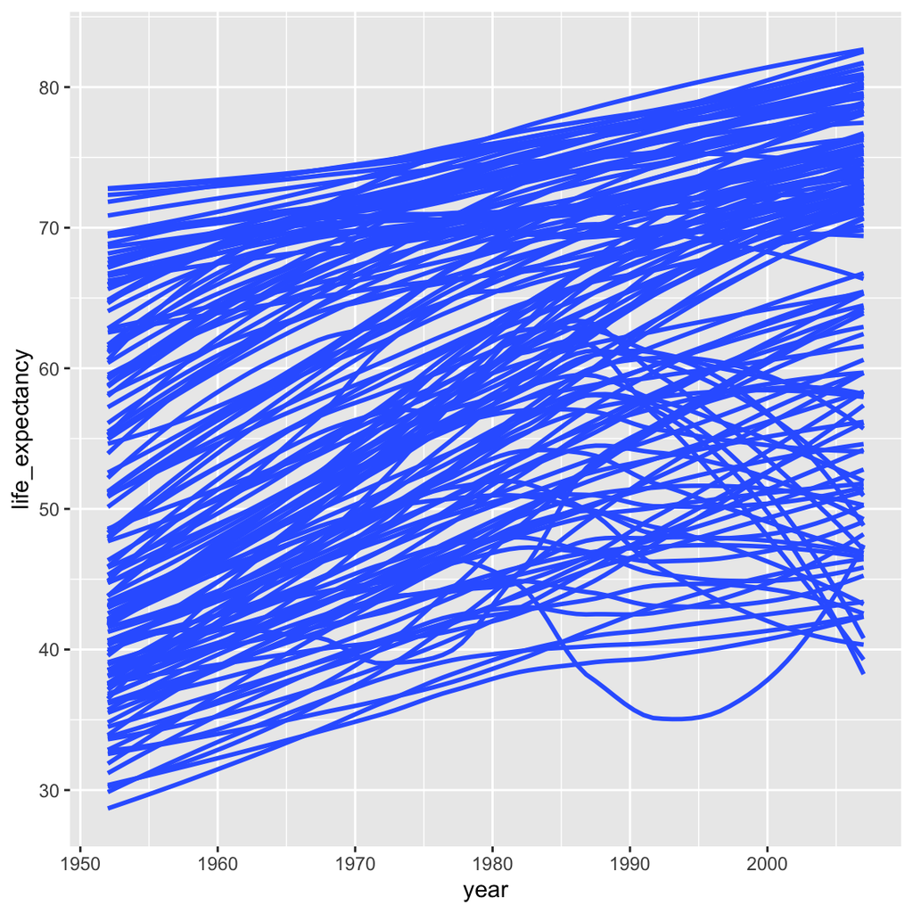

```r
development %>%
  ggplot(aes(year, life_expectancy, group=country)) +
  geom_smooth(se=FALSE)
```

**Explanation of the code**: We have created an x/y plot as before, but this time we only added `geom_smooth` (and not `geom_point`), so we can’t see the individual datapoints. We have also added the text `group=country` which means we see one line per-country in the dataset. Finally, we also added `se=FALSE`. This hides the shaded area which `geom_smooth` adds by default.

**Explanation of the output**: We see smoothed lines (one for each country) rather than points. It’s pretty hard to distinguish different countries or make sense of anything!

To increase the information density, and explore patterns within the data, we might add another dimension and aesthetic. The next plot colours each line by continent:

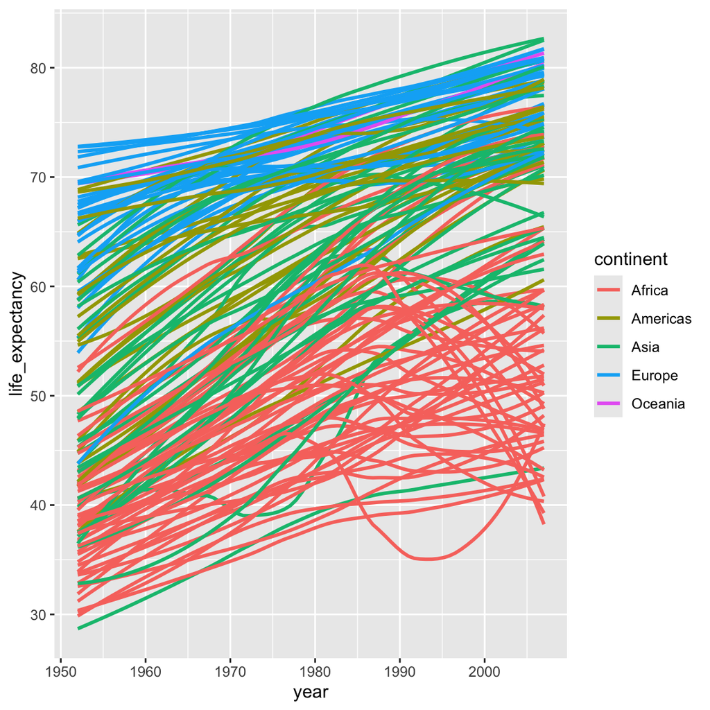

```r
development %>%
  ggplot(aes(year, life_expectancy, colour=continent, group=country)) +
  geom_smooth(se=FALSE)
```

However, even with colours added it’s still a bit of a mess. We can’t see the differences between continents very easily.

To clean things up we can use a technique called **faceting**.

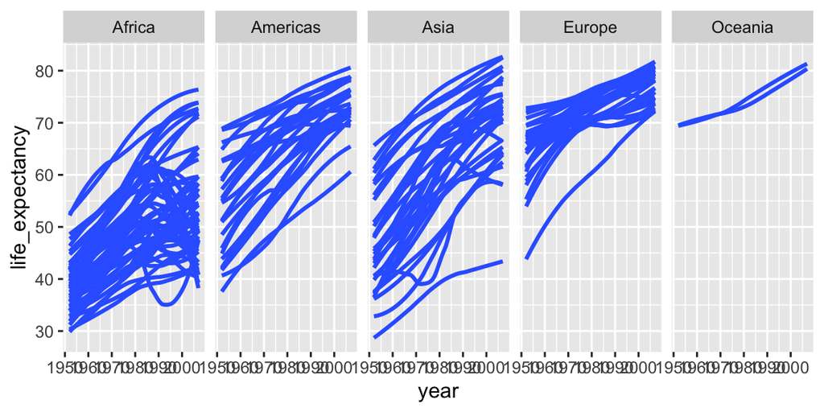

```r
development %>%
  ggplot(aes(year, life_expectancy, group=country)) +
  geom_smooth(se=FALSE) +
  facet_grid(~continent)
```

**Explanation**: We added the code `+ facet_grid(~continent)` to our previous plot, and removed the color aesthetic. This made `ggplot` create individual *panels* for each continent. Splitting the graph this way makes it somewhat easier to compare the differences *between* continents.

### Try facetting yourself

Use the `iris` dataset, which is built into R.

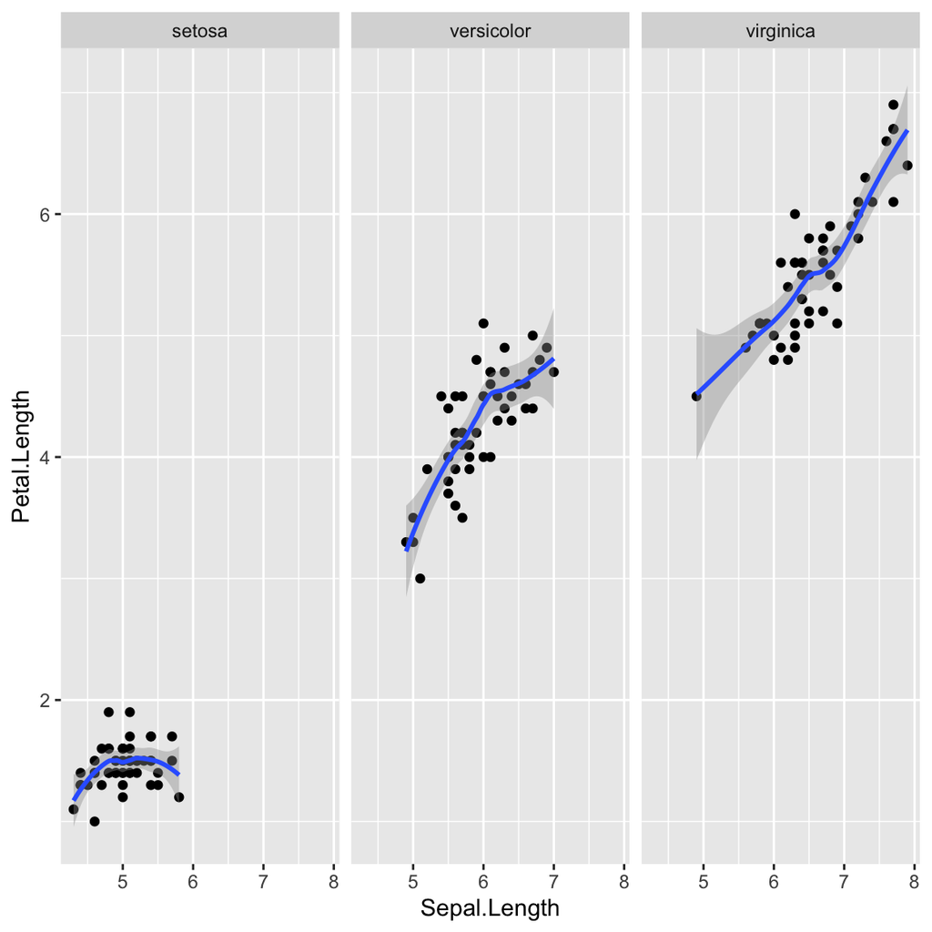

1. Try to recreate this plot by adapting the code shown for the `development` dataset above
2. Create a second plot which uses colours to distinguish species and does not use Facets
3. Which plot do you prefer — faceted or coloured? What might influence when facets are more useful than just using colour?

```r
iris %>%
  ggplot(aes(Sepal.Length, Petal.Length)) +
  geom_point()  +
  geom_smooth() +
  facet_grid(~Species)
```

```r
iris %>%
  ggplot(aes(Sepal.Length, Petal.Length, color=Species)) +
  geom_point()  +
  geom_smooth()
```

There’s no single right answer here, but for this example I prefer the coloured plot to the faceted one. The reason is that there are only 3 species in this dataset, and the points for each don’t overlap much. This means it is easy to distinguish them, even in the combined plot.

However, if there were *many* different species it might be helpful to use facets instead.

Our decisions should be driven by what we are trying to communicate with the plot. What was the research question that motivated us to draw it?

### Adjusting facets

In the explanation above, we saw this plot:

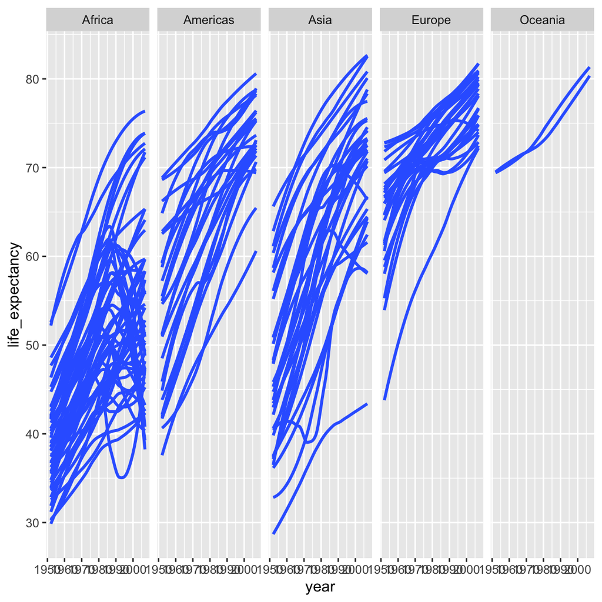

```r
development %>%
  ggplot(aes(year, life_expectancy, group=country)) +
  geom_smooth(se=FALSE) +
  facet_grid(~continent)
```

Re-run the plot and make the following adaptations:

1. Try replacing `facet_grid(~continent)` with `facet_grid(continent~.)`. What happens?
2. Try replacing `facet_grid` with `facet_wrap(~continent)`. What happens?
3. If you have time (as an extension exercise), you can see more faceting examples in the `ggplot` cookbook documentation. Try to re-create some of these examples.

# Comparing categories

In the examples above we have mostly been plotting continuous variables (and adding colours etc), using histograms, scatter plots and smoothed lines.

Another common requirement is to use plots to *compare* summary statistics for different *groups* or *categories.*

For example, the classic plot in a psychology journal looks something like this:

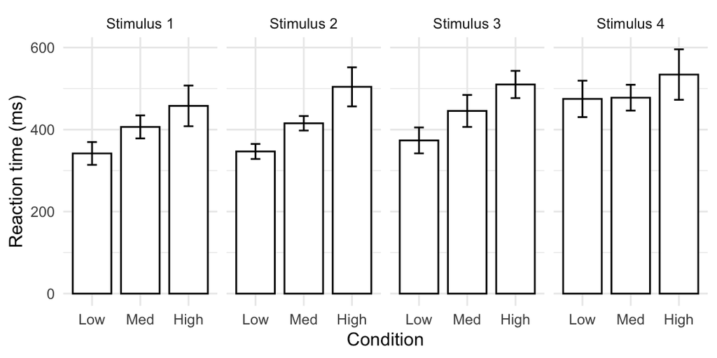

However, there is evidence that readers often misinterpret bar plots. Specifically, the problem is that [we perceive values *within* the bar area as more *likely* than those just above, even though this is not in fact the case](https://link.springer.com/article/10.3758/s13423-012-0247-5).

Often, a better choice is to use a [boxplot](https://en.wikipedia.org/wiki/Box_plot):

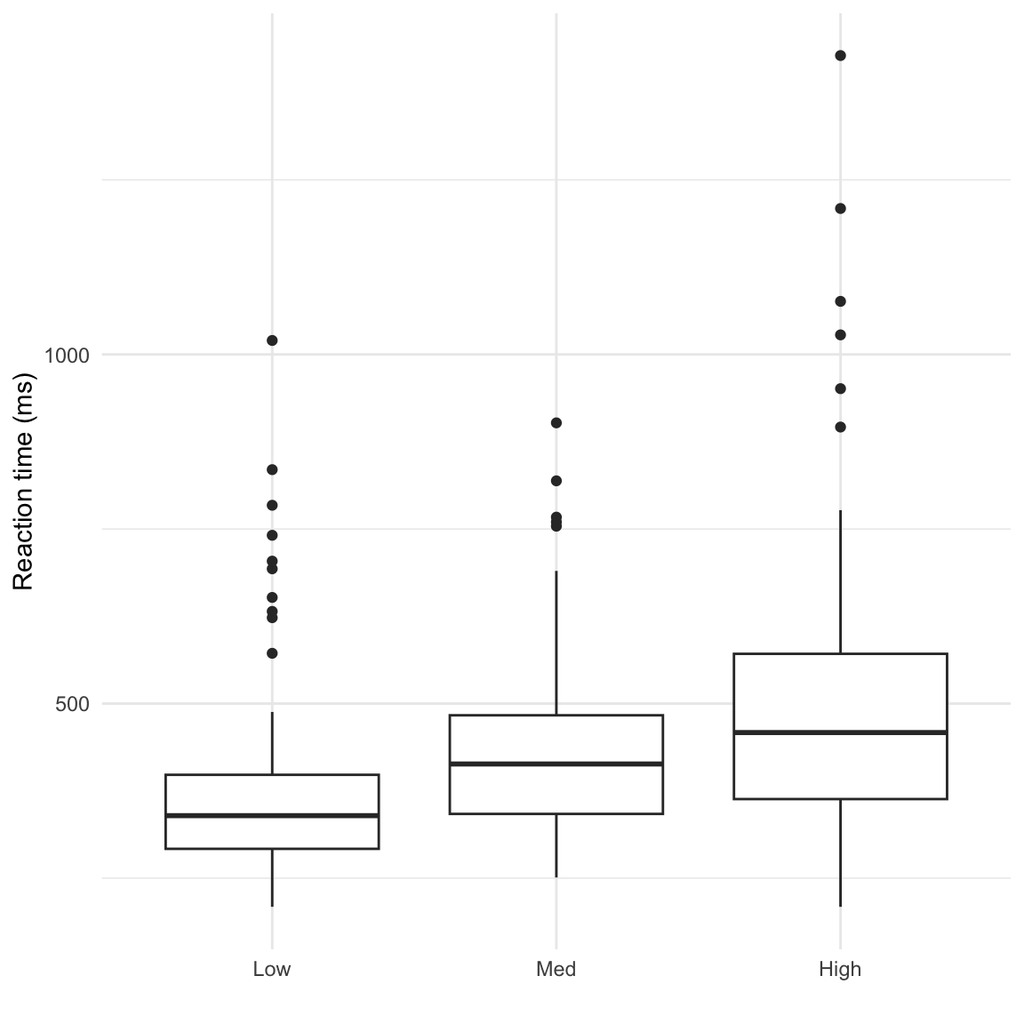

```r
expdata  %>%
  ggplot(aes(x=Condition, y=RT)) +
  geom_boxplot() +
  xlab("") +
  ylab("Reaction time (ms)") +
  theme_minimal()
```

**Explanation**: We used `Condition` (a category) as our x-axis, and reaction times as the y axis. We used `geom_boxplot` to show a boxplot. We haven’t yet split the plot by stimulus (we’ll do this below). The `theme_minimal()` function simplifies the appearance of the plot and removes the background color.

If you’re not familiar with boxplots, there are more details in the help files (type `?geom_boxplot` into the console) or use the [wikipedia page here](https://en.wikipedia.org/wiki/Box_plot)

### Loading data over the internet

So far we have always used data from the `psydata` package. However, we can also load data from files or over the internet using the `read_csv()` function. This is an example:

```r
expdata <- read_csv('https://benwhalley.github.io/datafluency/data/expdata.csv') %>%
  mutate(Condition = fct_relevel(Condition, "Low", "Med", "High"))
expdata %>% glimpse
```

```
Rows: 240
Columns: 4
$ Condition <fct> Low, Low, Low, Low, Low, Low, Low, Low, Low, Low, Low, Low, …
$ stimuli   <chr> "Stimulus 1", "Stimulus 1", "Stimulus 1", "Stimulus 1", "Sti…
$ p         <dbl> 1, 2, 3, 4, 5, 6, 7, 8, 9, 10, 11, 12, 13, 14, 15, 16, 17, 1…
$ RT        <dbl> 254, 368, 476, 209, 385, 394, 292, 294, 293, 271, 299, 265, …
```

*Explanation*: The part which starts `expdata <- read_csv('https://...` loads a CSV (data) file over the internet, and stores it in the variable called `expdata`. You can click [this link](https://benwhalley.github.io/datafluency/data/expdata.csv) to see the raw data. The `mutate(Condition = fct_relevel(...))` line sets the order of the `Condition` categories (otherwise R sorts them alphabetically: High, Low, Med), so plots show Low, Med, High from left to right. We then use `glimpse` to check the data.

Load the (simulated) dataset from this url: https://benwhalley.github.io/datafluency/data/expdata.csv (remember to set the order of the `Condition` categories, as shown above).

- Recreate the boxplot above
- Use a facet to recreate the plot you saw at the start of this section, enabling comparisons across `Condition` (on the x axis) and `stimuli` (in separate panels).

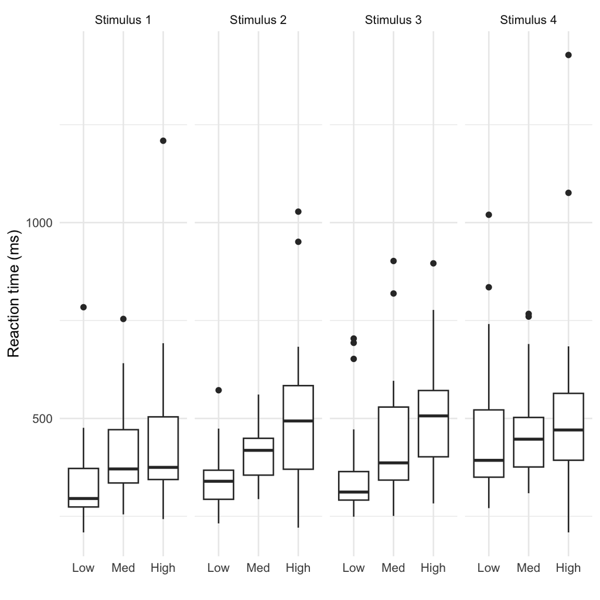

```r
expdata <- read_csv('https://benwhalley.github.io/datafluency/data/expdata.csv') %>%
  mutate(Condition = fct_relevel(Condition, "Low", "Med", "High"))

expdata  %>%
  ggplot(aes(x=Condition, y=RT)) +
  geom_boxplot() +
  xlab("") +
  ylab("Reaction time (ms)") +
  facet_wrap(~stimuli, nrow=1) +
  theme_minimal()
```

## Bar plots and other plots of summary data

If you wanted to plot the mean and standard error or standard deviations of different categories, ggplot also has the `stat_summary` command:

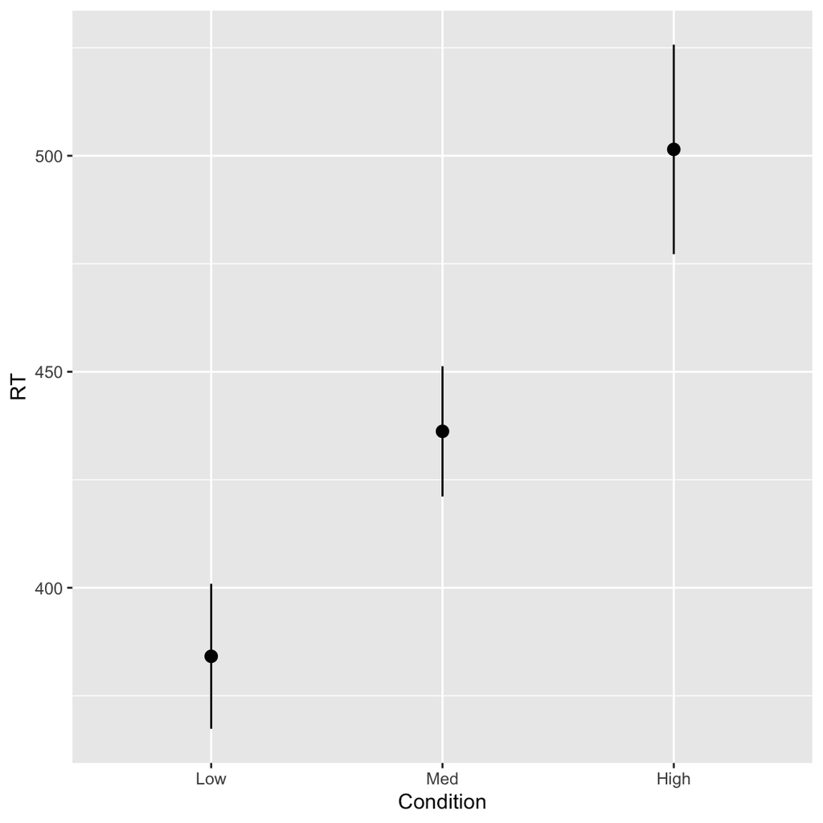

```r
expdata %>%
  ggplot(aes(Condition, RT)) +
  stat_summary()
```

**Explanation**: We used `Condition` and `RT` as our x and y axes, as before. This time we added `stat_summary()` instead of `geom_boxplot()`. By default this plots the mean and standard error (a measure of variability) in each group, using a **point-range plot**. This is better than a bar chart because it avoids a known bias in how we read them.

When you run this in RStudio you will see the message `No summary function supplied, defaulting to mean_se()`. This is not an error: it just tells you that ggplot is plotting the mean and standard error (`mean_se`) for each group.

Adapt your faceted boxplot from above to show the mean and standard error instead

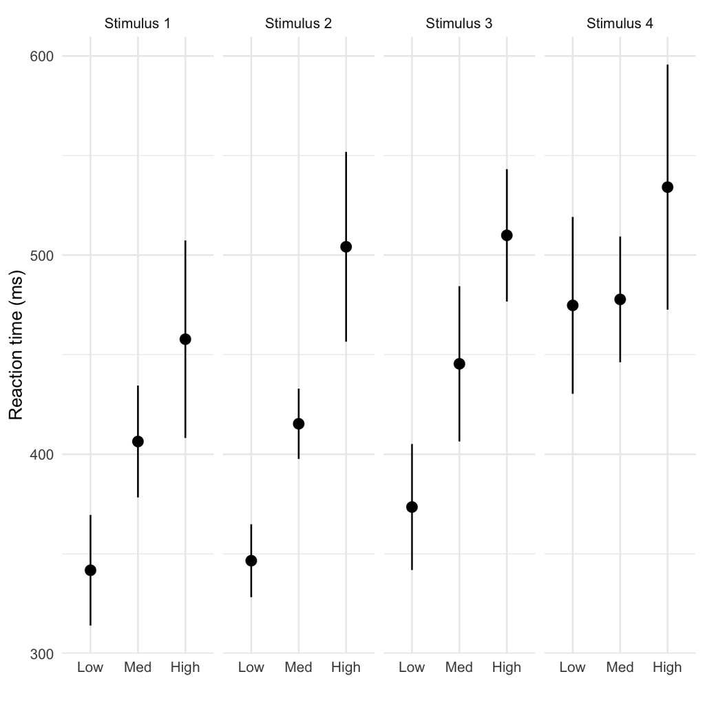

```r
expdata  %>%
  ggplot(aes(x=Condition, y=RT)) +
  stat_summary() +
  xlab("") +
  ylab("Reaction time (ms)") +
  facet_wrap(~stimuli, nrow=1) +
  theme_minimal()
```

#### Making bar plots

Although they are not recommended, `stat_summary` is a convenient way to produce bar plots.

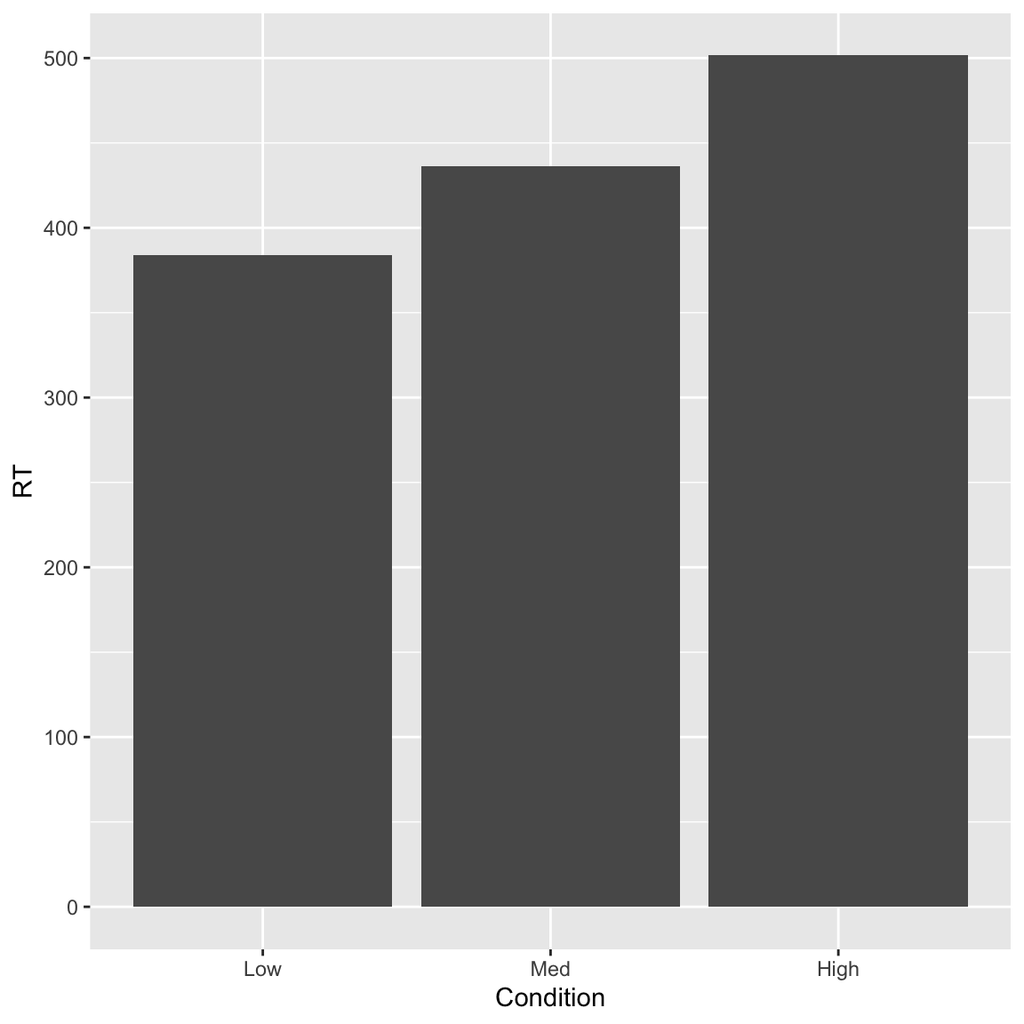

```r
expdata %>%
  ggplot(aes(Condition, RT)) +
  stat_summary(geom="bar")
```

And you can combine multiple calls to `stat_summary` to get a bar chart with error bars on top:

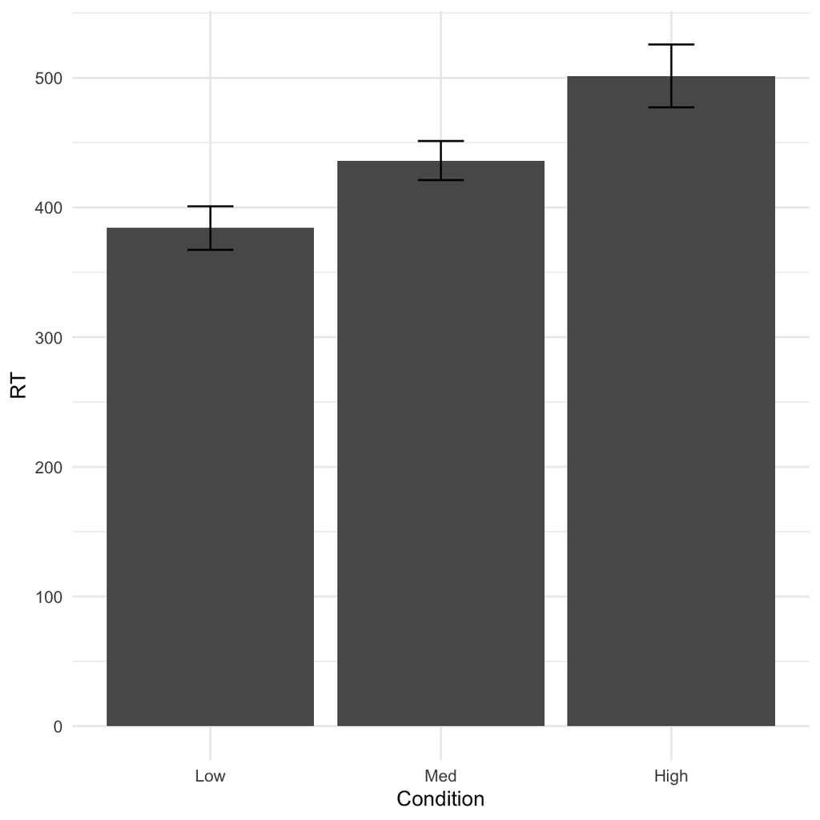

```r
expdata %>%
  ggplot(aes(Condition, RT)) +
  stat_summary(geom="bar") +
  # narrower width looks neater
  stat_summary(geom="errorbar", width=.2) +
  theme_minimal()
```